# vfrench3_OriginalHomeworkCode_05

Victoria French

11/4/2021

# Homework 5: Boots for Days

## Bootstrapping Standard Errors and CIs for Linear Models

When we initially discussed the central limit theorem and confidence intervals, we showed how we could use bootstrapping to estimate standard errors and confidence intervals around certain parameter values, like the mean. Using bootstrapping, we could also do the same for estimating standard errors and CIs around regression parameters, such as β coefficients.

```r
library(curl)
```

[1] Using the “KamilarAndCooperData.csv” dataset, run a linear regression looking at log(HomeRange_km2) in relation to log(Body_mass_female_mean) and report your β coeffiecients (slope and intercept).

```r
d <- curl('https://raw.githubusercontent.com/fuzzyatelin/fuzzyatelin.github.io/master/AN588_Fall21/KamilarAndCooperData.csv')
d <- read.csv(d, stringsAsFactors = FALSE, header = TRUE)
```

```r
x <- log(d$Body_mass_female_mean)
y <- log(d$HomeRange_km2)
```

```r
m <- lm(y ~ x)
summary(m)
```

```
##
## Call:
## lm(formula = y ~ x)
##
## Residuals:
##     Min      1Q  Median      3Q     Max
## -3.3929 -0.9433 -0.0126  1.0944  3.6826
##
## Coefficients:
##             Estimate Std. Error t value Pr(>|t|)
## (Intercept) -9.44123    0.67293  -14.03   <2e-16 ***
## x            1.03643    0.08488   12.21   <2e-16 ***
## ---
## Signif. codes:  0 '***' 0.001 '**' 0.01 '*' 0.05 '.' 0.1 ' ' 1
##
## Residual standard error: 1.423 on 135 degrees of freedom
##   (76 observations deleted due to missingness)
## Multiple R-squared:  0.5248, Adjusted R-squared:  0.5213
## F-statistic: 149.1 on 1 and 135 DF,  p-value: < 2.2e-16
```

```r
c <- coef(m)
c
```

```
## (Intercept)           x
##   -9.441231    1.036432
```

[2] Then, use bootstrapping to sample from your data 1000 times with replacement, each time fitting the same model and calculating the same coefficients. This generates a sampling distribution for each β coefficient.

```r
set.seed(1)
i.set <- NULL
s.set <- NULL
n <- 50
for (i in 1:1000) {
  #Sample the data rows so x and y measurements stay paired
    data <- d[sample(1:nrow(d), n, replace = TRUE),]
   #log transform the variables
    y <- log(data$HomeRange_km2)
    x <- log(data$Body_mass_female_mean)
    #Run a regression and extract the coefficients
    a <- as.data.frame(coef(lm(y~x)))
    #Place the coefficients into their respective sets
    i.set[i] <- a[1,] #Intercept
    s.set[i] <- a[2,] #Slope
}
```

Estimate the standard error for each of your β coefficients as the standard deviation of the sampling distribution from your bootstrap

```r
sd(i.set)
```

```
## [1] 1.369699
```

```r
sd(s.set)
```

```
## [1] 0.1744981
```

How does the former compare to the SE estimated from your entire dataset using the formula for standard error implemented in lm().

```r
f <- as.data.frame(coef(summary(m)))
f[1,2] #intercept standard error estimate
```

```
## [1] 0.6729346
```

```r
f[2,2] #slope standard error estimate
```

```
## [1] 0.08487709
```

Both estimates from the model are not close to the estimates generated from bootstrapping? Even though they should be in theory. I think I did something wrong.

Determine the 95% CI for each of your β coefficients based on the appropriate quantiles from your sampling distribution.

```r
quantile(i.set, c(0.025, 0.975))
```

```
##       2.5%      97.5%
## -12.364547  -6.932366
```

```r
quantile(s.set, c(0.025, 0.975))
```

```
##      2.5%     97.5%
## 0.7154393 1.4021961
```

The estimate of ~ -9 for the intercept from the entire data set fits into this confidence interval

The estimate of ~ 1 for the slope from the entire data set fits into this confidence interval

How does the latter compare to the 95% CI estimated from your entire dataset?

```r
confint(m, level = .95)
```

```
##                   2.5 %    97.5 %
## (Intercept) -10.7720889 -8.110374
## x             0.8685707  1.204292
```

Much closer than the SE estimates but still some variation from the model.

## Extra Credit

Write a FUNCTION that takes as its arguments a dataframe, “d”, a linear model, “m” (as a character string, e.g., “logHR~logBM”), a user-defined confidence interval level, “conf.level” (with default = 0.95), and a number of bootstrap replicates, “n” (with default = 1000). Your function should return a dataframe that includes: beta coefficient names; beta coefficients, standard errors, and upper and lower CI limits for the linear model based on your entire dataset; and mean beta coefficient estimates, SEs, and CI limits for those coefficients based on your bootstrap.

```r
linear.regression <- function(d, m, conf.level = 0.95, n = 1000, size = 50) {
  #Run Linear Regression
  model <- lm(formula = m, data = d, na.action = na.omit)

  #Extract Coefficients
  t <- as.data.frame(coef(summary(model)))
  #Extract CIs for the estimates
  c <- as.data.frame(confint(model, level = conf.level))
  #Generate a dataframe containing both the coefficients and the CIs
  return <- cbind(t,c)

#Run Bootstrap
i.set <- NULL
s.set <- NULL
for (i in 1:n) {
  #Sample the data rows so x and y measurements stay paired
    data <- d[sample(1:nrow(d), size, replace = TRUE),]
    #Run a regression and extract the coefficients
    a <- as.data.frame(coef(lm(formula = m, data = data)))
    #Place the coefficients into their respective sets
    i.set[i] <- a[1,] #Intercept
    s.set[i] <- a[2,] #Slope
}

#Estimate mean Beta coefficients from the sampling distribution
Intercept.estimate <- mean(i.set)
Slope.estimate <- mean(s.set)
#Estimate Standard error from sampling distribution by taking the standard deviation
Intercept.SE <- sd(i.set)
Slope.SE <- sd(s.set)
#Estimate CIs from sampling distribution
lower <- (1-conf.level)/2
upper <- 1-((1-conf.level)/2)
Intercept.CIs <- quantile(i.set, c(lower, upper))
Slope.CIs <- quantile(s.set, c(lower, upper))

#Construct the returned data frame
g <- t(data.frame(c(Intercept.estimate, Intercept.SE, Intercept.CIs), c(Slope.estimate, Slope.SE, Slope.CIs)))
return <- cbind(g,return)
rownames(return) <- c('Intercept', 'Slope')
colnames(return) <- c('Sample.Estimate', 'Sample.SE', 'Sample.CIlwr', 'Sample.CIupr', 'Model.Estimate', 'Model.SE', 'Model.tvalue', 'Model.pvalue', 'Model.lwr', 'Model.upr')

return <- return[, c(5,6,7,8,9,10,1,2,3,4)]
return
}
```

```r
#Testing the function
r <- linear.regression(d = d, m = log(HomeRange_km2) ~ log(Body_mass_female_mean))
r
```

```
##           Model.Estimate   Model.SE Model.tvalue Model.pvalue   Model.lwr
## Intercept      -9.441231 0.67293459    -14.02994 3.820677e-28 -10.7720889
## Slope           1.036432 0.08487709     12.21097 1.447292e-23   0.8685707
##           Model.upr Sample.Estimate Sample.SE Sample.CIlwr Sample.CIupr
## Intercept -8.110374       -9.469142  1.336390  -12.3501484    -7.025181
## Slope      1.204292        1.037810  0.170297    0.7218748     1.384131
```

## Extra Extra Credit

Graph each beta value from the linear model and its corresponding mean value, lower CI and upper CI from a bootstrap as a function of number of bootstraps from 10 to 200 by 10s. HINT: the beta value from the linear model will be the same for all bootstraps and the mean beta value may not differ that much!

```r
library(ggplot2)
```

```r
#Run the linear regression for different sample sizes 10 to 200 by 10
models <- NULL
for (i in seq(10,200,by =10)) {
  models[[i]] <- linear.regression(d = d, m = log(HomeRange_km2) ~ log(Body_mass_female_mean), size = i)
}
#Extract the models out of the 200 elements generated
models <- models[seq(10,200,by =10)]
```

This is me trying to extract the appropriate information from the models list. But this returns a list object and you cannot plot lists in ggplot objects

```r
#Extract the beta value, mean estimate and CIs from the models for the intercept
Beta0 <- NULL
for (i in 1:20) {
Beta0[[i]] <- models[[i]][1,c(1,7,9,10)]
}
```

```r
#Extract the beta value, mean estimate and CIs from the models for the slope
Beta1 <- NULL
for (i in 1:20) {
 Beta1[[i]] <- models[[i]][2,c(1,7,9,10)]
}
```

So I decided to try the lapply function to create a dataframe.

```r
#Creating a character vector so I can name the variables by their bootstrapping sample size.
char <- as.character(seq(10,200, by = 10))
```

```r
#Extracting the model estimate using the lapply function
est <- data.frame(lapply(models, `[[`, 1))
#renaming the rows and columns so I can bind the individual element data frames
rownames(est) <- c('Beta0.Est', 'Beta1.Est')
colnames(est) <- char

#repeat for each element
mean <- data.frame(lapply(models, `[[`, 7))
rownames(mean) <- c('Beta0.mean', 'Beta1.mean')
colnames(mean) <- char
lwr <- data.frame(lapply(models, `[[`, 9))
rownames(lwr) <- c('Beta0.lwr', 'Beta1.lwr')
colnames(lwr) <- char
upr <- data.frame(lapply(models, `[[`, 10))
rownames(upr) <- c('Beta0.upr', 'Beta1.upr')
colnames(upr) <- char
#Bind element dataframes into one dataframe to use for ggplots
data <- as.data.frame(t(rbind(est, mean, lwr, upr)))
#Adding in a variable of the numerical sequence because if I try to plot by rownames, ggplot will put them in 'alphabetical' versus 'numerical' order (x axis went 10,100,110,120,130, etc. instead of 10,20,30)
data$Sample.size <- seq(10,200, by = 10)
```

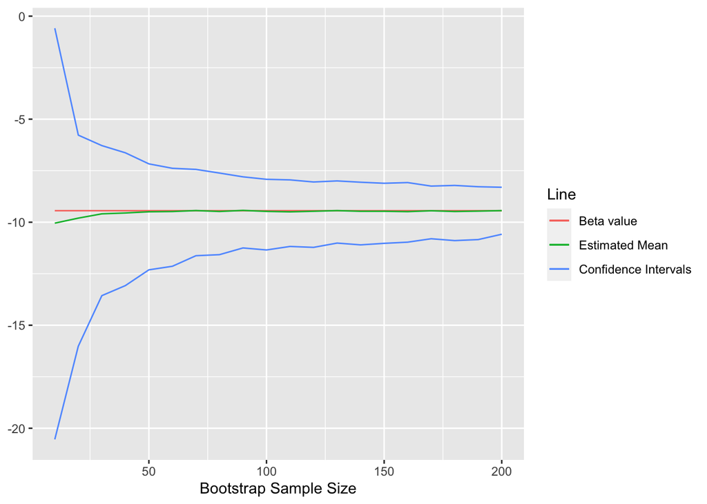

```r
#Create initial ggplot object and add in additional lines for each associated element
g <- ggplot(data = data, aes(x = Sample.size, y = Beta0.lwr)) +
    geom_line(aes(color = 'red')) +
    geom_line(data = data, aes(x = Sample.size, y = Beta0.upr, color = 'red')) +
    geom_line(data = data, aes(x = Sample.size, y = Beta0.Est, color = 'blue')) +
    geom_line(data = data, aes(x = Sample.size, y = Beta0.mean, color = 'green')) +
  labs(x = 'Bootstrap Sample Size', y = NULL) +
  scale_color_discrete(name="Line",
                         breaks=c("blue", "green", "red"),
                         labels=c("Beta value", "Estimated Mean", "Confidence Intervals"))
g
```

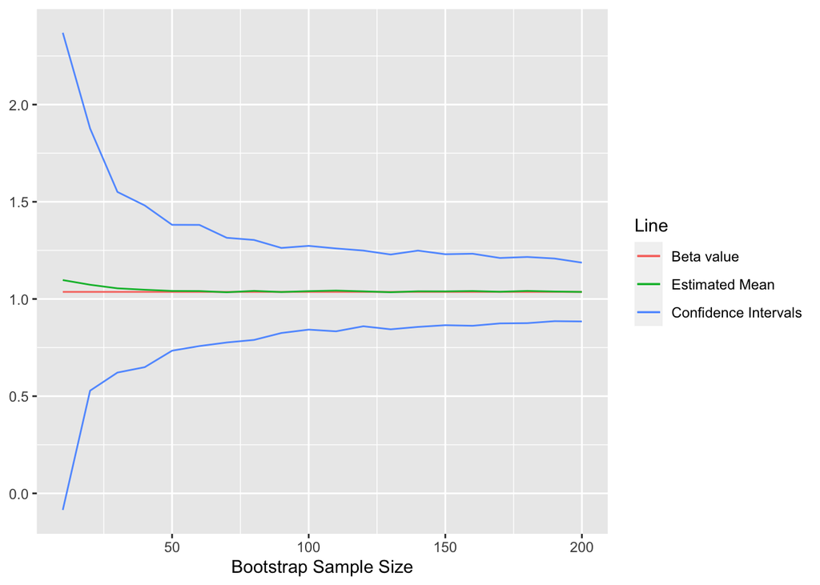

```r
#Repeat for Beta1

g <- ggplot(data = data, aes(x = Sample.size, y = Beta1.lwr)) +
    geom_line(aes(color = 'red')) +
    geom_line(data = data, aes(x = Sample.size, y = Beta1.upr, color = 'red')) +
    geom_line(data = data, aes(x = Sample.size, y = Beta1.Est, color = 'blue')) +
    geom_line(data = data, aes(x = Sample.size, y = Beta1.mean, color = 'green')) +
  labs(x = 'Bootstrap Sample Size', y = NULL) +
  scale_color_discrete(name="Line",
                         breaks=c("blue", "green", "red"),
                         labels=c("Beta value", "Estimated Mean", "Confidence Intervals"))
g
```

We can see from these visualizations that the sample size is not effecting the mean estimates but higher sample sizes do give us narrower confidence intervals.

# Challenges

1. The bootstrapping estimates. Intially I was sampling the x and the y variable separately which was giving me estimates completely different from the model estimates. They still aren’t perfectly aligned with the model estimates but they are much closer.
2. Generating a model. Originally I tried to write the function without the help of the lm function and I couldn’t figure out how to do it.
3. I still don’t get how you would utilize the formula argument if it was a character vector?
4. ggplot!! Specifically figuring out what format worked best for extracting the variables and figuring out how to ordering them in the plot.